# Analysis

[figure not shown]

### Data Collection

Data was downloaded from BigQuery's publicly available dataset. Kaggle was used to extract the data, as they have a free integration with BigQuery. My script for downloading the data is [here.](https://www.kaggle.com/benjamincabalonajr/nyc-taxi)

We ended up having 2 datasets:

- Attributes related to trips per a given time point.
- Geometric data.

We'll be building a regression model to predict `fare_amount`. We'll also look at some interesting properties/patterns that has something to do with the geometric data.

The first few rows of these datasets are shown below.

|  | pickup | dropoff | rate_code | passenger_count | trip_distance | fare_amount | tip_amount | payment_type | pickup_id | dropoff_id |
| --- | --- | --- | --- | --- | --- | --- | --- | --- | --- | --- |
| 0 | 2018-01-01 | 2018-01-01 00:49:42 | 1 | 2 | 17.70 | 53.5 | 0.0 | 2 | 247 | 33 |
| 1 | 2018-01-01 | 2018-01-01 07:09:17 | 5 | 1 | 0.00 | 60.0 | 0.0 | 1 | 80 | 80 |
| 2 | 2018-01-01 | 2018-01-01 15:03:44 | 3 | 2 | 14.70 | 63.0 | 0.0 | 5 | 1 | 33 |
| 5 | 2018-01-07 | 2018-01-07 11:21:47 | 5 | 1 | 0.01 | 55.0 | 0.0 | 2 | 215 | 215 |
| 6 | 2018-01-07 | 2018-01-07 18:35:42 | 5 | 1 | 11.78 | 55.0 | 0.0 | 2 | 138 | 136 |

|  | zone_id | zone_name | borough | zone_geom |
| --- | --- | --- | --- | --- |
| 0 | 1 | Newark Airport | EWR | POLYGON((-74.1856319999999 40.6916479999999, -... |
| 1 | 3 | Allerton/Pelham Gardens | Bronx | POLYGON((-73.848596761 40.8716707849999, -73.8... |
| 2 | 18 | Bedford Park | Bronx | POLYGON((-73.8844286139999 40.8668003789999, -... |
| 3 | 20 | Belmont | Bronx | POLYGON((-73.8839239579998 40.8644177609999, -... |
| 4 | 31 | Bronx Park | Bronx | POLYGON((-73.8710017319999 40.8572767429999, -... |

### Data Cleaning

- Incorrect dates.
  - We'll limit the dataset for the year 2018 only.
- Max `fare_amount` is ~$4,300.
  - We'll only consider fare amounts that are less than the 99th percentile.

```
minimum date 2008-12-31 00:00:00
maxmium date 2081-06-24 00:00:00
```

|  | rate_code | passenger_count | trip_distance | fare_amount | tip_amount | payment_type | pickup_id | dropoff_id |
| --- | --- | --- | --- | --- | --- | --- | --- | --- |
| count | 483005.000000 | 483005.000000 | 483005.000000 | 483005.000000 | 483005.000000 | 483005.000000 | 483005.000000 | 483005.000000 |
| mean | 1.462467 | 1.333489 | 10.384775 | 36.575097 | 1.976814 | 1.204971 | 133.645703 | 119.145344 |
| std | 1.402275 | 0.995965 | 5.327600 | 18.753280 | 3.731926 | 0.415559 | 74.992084 | 76.406088 |
| min | 1.000000 | 0.000000 | 0.000000 | 0.010000 | 0.000000 | 1.000000 | 1.000000 | 1.000000 |
| 25% | 1.000000 | 1.000000 | 7.220000 | 27.500000 | 0.000000 | 1.000000 | 70.000000 | 55.000000 |
| 50% | 1.000000 | 1.000000 | 9.300000 | 32.500000 | 0.000000 | 1.000000 | 133.000000 | 95.000000 |
| 75% | 1.000000 | 1.000000 | 12.890000 | 43.000000 | 4.000000 | 1.000000 | 197.000000 | 183.000000 |
| max | 99.000000 | 9.000000 | 235.700000 | 4307.000000 | 444.440000 | 5.000000 | 265.000000 | 265.000000 |

```
fare_amount 99th percentile 84.0
```

Let's look at the distribution of `fare_amount` after data cleaning. Now the data makes more sense. We have a lower bound at zero, and we observe a distribution that's close to an exponential distribution from ~25 onwards.

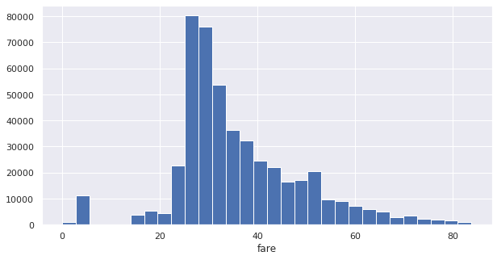

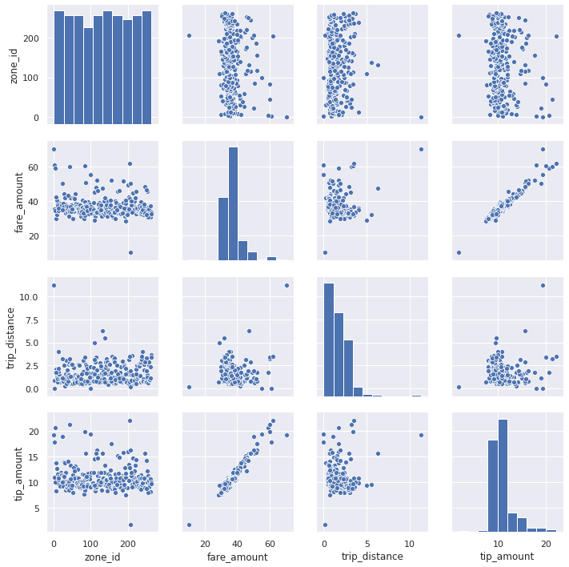

# Geometric Properties

Now we will plot the average of the trip attributes together with the geometric data. To summarize the charts below, it is clear that there are some interesting patterns that can be observed. (i.e. It shows that some zone ID's have a relatively higher average `fare_amount`)

Note: The process of plotting the geometric data and trip attributes can be made interactive. However, since we're not allowed to share this notebook on a public repository, i can't use `Viola` to serve an interactive jupyter notebook.

### Different Boroughs in New York City

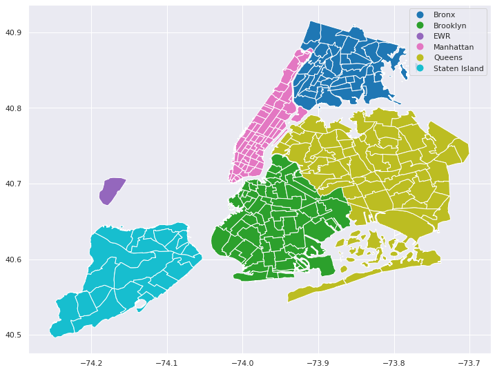

### Average Fare Amount for New York City

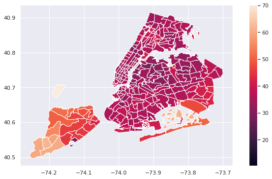

### Average Trip Distance for New York City

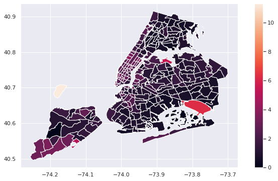

### Average Tip Amount for New York City

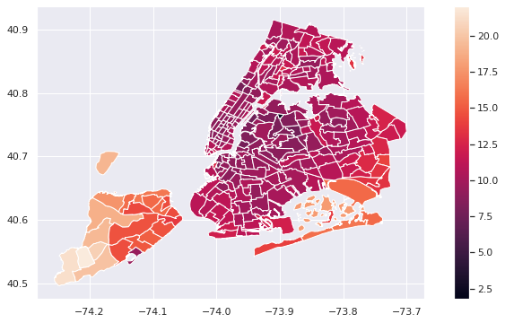

### Machine Learning

First, we fit a linear regression model. We obtained a satisfactory performance. Our RMSE (both on Cross Validation and Testing) is just less than $2. This performance is great considering the distribution of the `fare_amount`.

#### SKLEARN FIT (Splitting the dataset to train and testing)

```
Model RMSE with 3 cross validation : 1.8479621163826945
Model Test RMSE 1.8401913328109212
Average Salary in the Dataset 37.02352364678449
```

#### Fitting the entire dataset with R. (For better interpretability)

- Coefficients are statistically significant, except for `zone_id.` As expected, `tip_amount` has the highest positive coefficient.

```
Call:
lm(formula = fare_amount ~ tip_amount + trip_distance + zone_id,
    data = data)

Residuals:
    Min      1Q  Median      3Q     Max
-5.9955 -0.9052 -0.0922  0.9730  9.6500

Coefficients:
               Estimate Std. Error t value Pr(>|t|)
(Intercept)   10.900811   0.545341  19.989  < 2e-16 ***
tip_amount     2.368028   0.043397  54.566  < 2e-16 ***
trip_distance  0.362769   0.090533   4.007 8.07e-05 ***
zone_id       -0.001075   0.001389  -0.774     0.44
---
Signif. codes:  0 ‘***’ 0.001 ‘**’ 0.01 ‘*’ 0.05 ‘.’ 0.1 ‘ ’ 1

Residual standard error: 1.692 on 255 degrees of freedom
Multiple R-squared:  0.9234,	Adjusted R-squared:  0.9225
F-statistic:  1025 on 3 and 255 DF,  p-value: < 2.2e-16
```